# SIR model

[figure not shown]

## Quickstart

There are already several compartmental models implemented in the library, among which the simple SIR model.  
You can easily use and play with this model.

```
# To get development library
# Ignore those two rows if you are not library contributor
import sys
sys.path.append("../../")
sys.path.append("../")


# Import library
from pyepidemics.models import SIR
```

There are three parameters to set :

- $N$ the population considered
- $\beta$ the contagion parameter, ie how many people do you infect per day
- $\gamma$ the recovery rate, ie 1/duration of the infection before the end of contagion phase

```
# Let's take approximate parameters during COVID19 epidemics
N = 67e6
beta = 3.3/4
gamma = 1/4

sir = SIR(N,beta,gamma)
```

We can simulate the propagation, with 1 infected at the start of the epidemics (shown as argument of the function `.solve()`)

```
states = sir.solve(1)
states.head()
```

|  | S | I | R |
| --- | --- | --- | --- |
| 0 | 6.700000e+07 | 1.000000 | 0.000000 |
| 1 | 6.700000e+07 | 1.777131 | 0.337883 |
| 2 | 6.700000e+07 | 3.158193 | 0.938345 |
| 3 | 6.699999e+07 | 5.612521 | 2.005444 |
| 4 | 6.699999e+07 | 9.974180 | 3.901818 |

Let's visualize the propagation, actually `states` is not a `pd.DataFrame` but a custom object with embedded visualizations.

```
states.show()
```

[interactive chart not shown]

## Deep-dives

### Visualizing the compartments network

You can visualize the transitions between states, for a SIR model it's straight forward but this function can be interesting for more complex model

```
sir.show_network()
```

```
[INFO] Displaying only the largest graph component, graphs may be repeated for each category
```

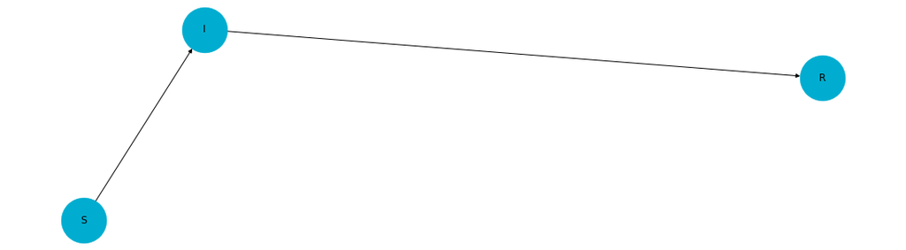

### .show() method

The `.show()` method allow for easy time series visualization with Plotly and matplotlib with many features

```
# Visualize with matplotlib
states.show(plotly = False)
```

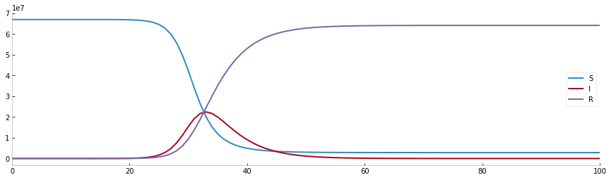

```
states.show(facet_row = "compartment")
```

[interactive chart not shown]

```
states.show(facet_col = "compartment")
```

[interactive chart not shown]

```
states.show(group = {"Infection":["I"],"Population":["S","R"]})
```

[interactive chart not shown]

### .solve() method

The `.solve()` method solve the differential equation behind SIR model.  
Just before we simply solved it with $I0=1$  
but we can initialize it differently for example to initialize with $I0 = 10$ there are several options:

```
I0 = 10

states = sir.solve(I0)
states = sir.solve((N-I0,I0,0))
states = sir.solve({"S":N-I0,"I":I0})
```

You can also specify :

- The number of forecasted days
- The start date

```
states = sir.solve(I0,n_days = 200,start_date = "2020-02-01")
states.show(plotly = False)
```

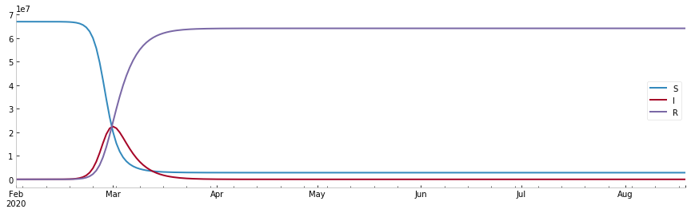